# Risk Factor Analysis

## Outcome Variable

**Outcome Variable:** ever_stunted

## Predictor Variables

**Intervention Variable:** month

**Adjustment Set:**

unadjusted

## Stratifying Variables

The analysis was stratified on these variable(s):

- agecat
- studyid
- country

## Data Summary

| agecat | studyid | country | A | n | nA | nAY0 | nAY1 |
| --- | --- | --- | --- | --- | --- | --- | --- |
| 3 months | ki0047075b-MAL-ED | BANGLADESH | 1 | 265 | 20 | 15 | 5 |
| 3 months | ki0047075b-MAL-ED | BANGLADESH | 2 | 265 | 24 | 16 | 8 |
| 3 months | ki0047075b-MAL-ED | BANGLADESH | 3 | 265 | 28 | 16 | 12 |
| 3 months | ki0047075b-MAL-ED | BANGLADESH | 4 | 265 | 22 | 22 | 0 |
| 3 months | ki0047075b-MAL-ED | BANGLADESH | 5 | 265 | 22 | 12 | 10 |
| 3 months | ki0047075b-MAL-ED | BANGLADESH | 6 | 265 | 9 | 5 | 4 |
| 3 months | ki0047075b-MAL-ED | BANGLADESH | 7 | 265 | 22 | 17 | 5 |
| 3 months | ki0047075b-MAL-ED | BANGLADESH | 8 | 265 | 25 | 15 | 10 |
| 3 months | ki0047075b-MAL-ED | BANGLADESH | 9 | 265 | 24 | 19 | 5 |
| 3 months | ki0047075b-MAL-ED | BANGLADESH | 10 | 265 | 24 | 17 | 7 |
| 3 months | ki0047075b-MAL-ED | BANGLADESH | 11 | 265 | 17 | 11 | 6 |
| 3 months | ki0047075b-MAL-ED | BANGLADESH | 12 | 265 | 28 | 22 | 6 |
| 3 months | ki0047075b-MAL-ED | BRAZIL | 1 | 233 | 13 | 12 | 1 |
| 3 months | ki0047075b-MAL-ED | BRAZIL | 2 | 233 | 26 | 21 | 5 |
| 3 months | ki0047075b-MAL-ED | BRAZIL | 3 | 233 | 21 | 17 | 4 |
| 3 months | ki0047075b-MAL-ED | BRAZIL | 4 | 233 | 11 | 10 | 1 |
| 3 months | ki0047075b-MAL-ED | BRAZIL | 5 | 233 | 24 | 20 | 4 |
| 3 months | ki0047075b-MAL-ED | BRAZIL | 6 | 233 | 8 | 6 | 2 |
| 3 months | ki0047075b-MAL-ED | BRAZIL | 7 | 233 | 19 | 14 | 5 |
| 3 months | ki0047075b-MAL-ED | BRAZIL | 8 | 233 | 21 | 18 | 3 |
| 3 months | ki0047075b-MAL-ED | BRAZIL | 9 | 233 | 31 | 24 | 7 |
| 3 months | ki0047075b-MAL-ED | BRAZIL | 10 | 233 | 22 | 20 | 2 |
| 3 months | ki0047075b-MAL-ED | BRAZIL | 11 | 233 | 19 | 19 | 0 |
| 3 months | ki0047075b-MAL-ED | BRAZIL | 12 | 233 | 18 | 14 | 4 |
| 3 months | ki0047075b-MAL-ED | INDIA | 1 | 251 | 20 | 12 | 8 |
| 3 months | ki0047075b-MAL-ED | INDIA | 2 | 251 | 21 | 21 | 0 |
| 3 months | ki0047075b-MAL-ED | INDIA | 3 | 251 | 22 | 16 | 6 |
| 3 months | ki0047075b-MAL-ED | INDIA | 4 | 251 | 18 | 13 | 5 |
| 3 months | ki0047075b-MAL-ED | INDIA | 5 | 251 | 8 | 7 | 1 |
| 3 months | ki0047075b-MAL-ED | INDIA | 6 | 251 | 19 | 17 | 2 |

[output cut: 1566 more lines]

The following strata were considered:

- agecat: 12 months, studyid: ki0047075b-MAL-ED, country: BANGLADESH
- agecat: 12 months, studyid: ki0047075b-MAL-ED, country: BRAZIL
- agecat: 12 months, studyid: ki0047075b-MAL-ED, country: INDIA
- agecat: 12 months, studyid: ki0047075b-MAL-ED, country: NEPAL
- agecat: 12 months, studyid: ki0047075b-MAL-ED, country: PERU
- agecat: 12 months, studyid: ki0047075b-MAL-ED, country: SOUTH AFRICA
- agecat: 12 months, studyid: ki0047075b-MAL-ED, country: TANZANIA, UNITED REPUBLIC OF
- agecat: 12 months, studyid: ki1000108-CMC-V-BCS-2002, country: INDIA
- agecat: 12 months, studyid: ki1000108-IRC, country: INDIA
- agecat: 12 months, studyid: ki1000109-EE, country: PAKISTAN
- agecat: 12 months, studyid: ki1000109-ResPak, country: PAKISTAN
- agecat: 12 months, studyid: ki1000304b-SAS-CompFeed, country: INDIA
- agecat: 12 months, studyid: ki1000304b-SAS-FoodSuppl, country: INDIA
- agecat: 12 months, studyid: ki1017093-NIH-Birth, country: BANGLADESH
- agecat: 12 months, studyid: ki1066203-TanzaniaChild2, country: TANZANIA, UNITED REPUBLIC OF
- agecat: 12 months, studyid: ki1112895-Guatemala BSC, country: GUATEMALA
- agecat: 12 months, studyid: ki1112895-iLiNS-Zinc, country: BURKINA FASO
- agecat: 12 months, studyid: ki1113344-GMS-Nepal, country: NEPAL
- agecat: 12 months, studyid: ki1114097-CMIN, country: BANGLADESH
- agecat: 12 months, studyid: ki1114097-CMIN, country: BRAZIL
- agecat: 12 months, studyid: ki1114097-CMIN, country: GUINEA-BISSAU
- agecat: 12 months, studyid: ki1114097-CMIN, country: PERU
- agecat: 12 months, studyid: ki1114097-CONTENT, country: PERU
- agecat: 12 months, studyid: ki1119695-PROBIT, country: BELARUS
- agecat: 12 months, studyid: ki1126311-ZVITAMBO, country: ZIMBABWE
- agecat: 12 months, studyid: ki1148112-LCNI-5, country: MALAWI
- agecat: 12 months, studyid: kiGH5241-JiVitA-3, country: BANGLADESH
- agecat: 12 months, studyid: kiGH5241-JiVitA-4, country: BANGLADESH
- agecat: 18 months, studyid: ki0047075b-MAL-ED, country: BANGLADESH
- agecat: 18 months, studyid: ki0047075b-MAL-ED, country: BRAZIL
- agecat: 18 months, studyid: ki0047075b-MAL-ED, country: INDIA
- agecat: 18 months, studyid: ki0047075b-MAL-ED, country: NEPAL
- agecat: 18 months, studyid: ki0047075b-MAL-ED, country: PERU
- agecat: 18 months, studyid: ki0047075b-MAL-ED, country: SOUTH AFRICA
- agecat: 18 months, studyid: ki0047075b-MAL-ED, country: TANZANIA, UNITED REPUBLIC OF
- agecat: 18 months, studyid: ki1000108-CMC-V-BCS-2002, country: INDIA
- agecat: 18 months, studyid: ki1000108-IRC, country: INDIA
- agecat: 18 months, studyid: ki1000109-EE, country: PAKISTAN
- agecat: 18 months, studyid: ki1000109-ResPak, country: PAKISTAN
- agecat: 18 months, studyid: ki1000304b-SAS-CompFeed, country: INDIA
- agecat: 18 months, studyid: ki1000304b-SAS-FoodSuppl, country: INDIA
- agecat: 18 months, studyid: ki1017093-NIH-Birth, country: BANGLADESH
- agecat: 18 months, studyid: ki1066203-TanzaniaChild2, country: TANZANIA, UNITED REPUBLIC OF
- agecat: 18 months, studyid: ki1112895-Guatemala BSC, country: GUATEMALA
- agecat: 18 months, studyid: ki1112895-iLiNS-Zinc, country: BURKINA FASO
- agecat: 18 months, studyid: ki1113344-GMS-Nepal, country: NEPAL
- agecat: 18 months, studyid: ki1114097-CMIN, country: BANGLADESH
- agecat: 18 months, studyid: ki1114097-CMIN, country: BRAZIL
- agecat: 18 months, studyid: ki1114097-CMIN, country: GUINEA-BISSAU
- agecat: 18 months, studyid: ki1114097-CMIN, country: PERU
- agecat: 18 months, studyid: ki1114097-CONTENT, country: PERU
- agecat: 18 months, studyid: ki1119695-PROBIT, country: BELARUS
- agecat: 18 months, studyid: ki1126311-ZVITAMBO, country: ZIMBABWE
- agecat: 18 months, studyid: ki1148112-LCNI-5, country: MALAWI
- agecat: 18 months, studyid: kiGH5241-JiVitA-3, country: BANGLADESH
- agecat: 18 months, studyid: kiGH5241-JiVitA-4, country: BANGLADESH
- agecat: 24 months, studyid: ki0047075b-MAL-ED, country: BANGLADESH
- agecat: 24 months, studyid: ki0047075b-MAL-ED, country: BRAZIL
- agecat: 24 months, studyid: ki0047075b-MAL-ED, country: INDIA
- agecat: 24 months, studyid: ki0047075b-MAL-ED, country: NEPAL
- agecat: 24 months, studyid: ki0047075b-MAL-ED, country: PERU
- agecat: 24 months, studyid: ki0047075b-MAL-ED, country: SOUTH AFRICA
- agecat: 24 months, studyid: ki0047075b-MAL-ED, country: TANZANIA, UNITED REPUBLIC OF
- agecat: 24 months, studyid: ki1000108-CMC-V-BCS-2002, country: INDIA
- agecat: 24 months, studyid: ki1000108-IRC, country: INDIA
- agecat: 24 months, studyid: ki1000109-EE, country: PAKISTAN
- agecat: 24 months, studyid: ki1000304b-SAS-CompFeed, country: INDIA
- agecat: 24 months, studyid: ki1000304b-SAS-FoodSuppl, country: INDIA
- agecat: 24 months, studyid: ki1017093-NIH-Birth, country: BANGLADESH
- agecat: 24 months, studyid: ki1066203-TanzaniaChild2, country: TANZANIA, UNITED REPUBLIC OF
- agecat: 24 months, studyid: ki1112895-iLiNS-Zinc, country: BURKINA FASO
- agecat: 24 months, studyid: ki1113344-GMS-Nepal, country: NEPAL
- agecat: 24 months, studyid: ki1114097-CMIN, country: BANGLADESH
- agecat: 24 months, studyid: ki1114097-CMIN, country: BRAZIL
- agecat: 24 months, studyid: ki1114097-CMIN, country: GUINEA-BISSAU
- agecat: 24 months, studyid: ki1114097-CMIN, country: PERU
- agecat: 24 months, studyid: ki1114097-CONTENT, country: PERU
- agecat: 24 months, studyid: ki1119695-PROBIT, country: BELARUS
- agecat: 24 months, studyid: ki1126311-ZVITAMBO, country: ZIMBABWE
- agecat: 24 months, studyid: ki1148112-LCNI-5, country: MALAWI
- agecat: 24 months, studyid: kiGH5241-JiVitA-3, country: BANGLADESH
- agecat: 24 months, studyid: kiGH5241-JiVitA-4, country: BANGLADESH
- agecat: 3 months, studyid: ki0047075b-MAL-ED, country: BANGLADESH
- agecat: 3 months, studyid: ki0047075b-MAL-ED, country: BRAZIL
- agecat: 3 months, studyid: ki0047075b-MAL-ED, country: INDIA
- agecat: 3 months, studyid: ki0047075b-MAL-ED, country: NEPAL
- agecat: 3 months, studyid: ki0047075b-MAL-ED, country: PERU
- agecat: 3 months, studyid: ki0047075b-MAL-ED, country: SOUTH AFRICA
- agecat: 3 months, studyid: ki0047075b-MAL-ED, country: TANZANIA, UNITED REPUBLIC OF
- agecat: 3 months, studyid: ki1000108-CMC-V-BCS-2002, country: INDIA
- agecat: 3 months, studyid: ki1000108-IRC, country: INDIA
- agecat: 3 months, studyid: ki1000109-EE, country: PAKISTAN
- agecat: 3 months, studyid: ki1000109-ResPak, country: PAKISTAN
- agecat: 3 months, studyid: ki1000304b-SAS-CompFeed, country: INDIA
- agecat: 3 months, studyid: ki1017093-NIH-Birth, country: BANGLADESH
- agecat: 3 months, studyid: ki1066203-TanzaniaChild2, country: TANZANIA, UNITED REPUBLIC OF
- agecat: 3 months, studyid: ki1113344-GMS-Nepal, country: NEPAL
- agecat: 3 months, studyid: ki1114097-CMIN, country: BANGLADESH
- agecat: 3 months, studyid: ki1114097-CMIN, country: BRAZIL
- agecat: 3 months, studyid: ki1114097-CMIN, country: GUINEA-BISSAU
- agecat: 3 months, studyid: ki1114097-CMIN, country: PERU
- agecat: 3 months, studyid: ki1114097-CONTENT, country: PERU
- agecat: 3 months, studyid: ki1119695-PROBIT, country: BELARUS
- agecat: 3 months, studyid: ki1126311-ZVITAMBO, country: ZIMBABWE
- agecat: 3 months, studyid: kiGH5241-JiVitA-3, country: BANGLADESH
- agecat: 3 months, studyid: kiGH5241-JiVitA-4, country: BANGLADESH
- agecat: 6 months, studyid: ki0047075b-MAL-ED, country: BANGLADESH
- agecat: 6 months, studyid: ki0047075b-MAL-ED, country: BRAZIL
- agecat: 6 months, studyid: ki0047075b-MAL-ED, country: INDIA
- agecat: 6 months, studyid: ki0047075b-MAL-ED, country: NEPAL
- agecat: 6 months, studyid: ki0047075b-MAL-ED, country: PERU
- agecat: 6 months, studyid: ki0047075b-MAL-ED, country: SOUTH AFRICA
- agecat: 6 months, studyid: ki0047075b-MAL-ED, country: TANZANIA, UNITED REPUBLIC OF
- agecat: 6 months, studyid: ki1000108-CMC-V-BCS-2002, country: INDIA
- agecat: 6 months, studyid: ki1000108-IRC, country: INDIA
- agecat: 6 months, studyid: ki1000109-EE, country: PAKISTAN
- agecat: 6 months, studyid: ki1000109-ResPak, country: PAKISTAN
- agecat: 6 months, studyid: ki1000304b-SAS-CompFeed, country: INDIA
- agecat: 6 months, studyid: ki1000304b-SAS-FoodSuppl, country: INDIA
- agecat: 6 months, studyid: ki1017093-NIH-Birth, country: BANGLADESH
- agecat: 6 months, studyid: ki1066203-TanzaniaChild2, country: TANZANIA, UNITED REPUBLIC OF
- agecat: 6 months, studyid: ki1112895-Guatemala BSC, country: GUATEMALA
- agecat: 6 months, studyid: ki1113344-GMS-Nepal, country: NEPAL
- agecat: 6 months, studyid: ki1114097-CMIN, country: BANGLADESH
- agecat: 6 months, studyid: ki1114097-CMIN, country: BRAZIL
- agecat: 6 months, studyid: ki1114097-CMIN, country: GUINEA-BISSAU
- agecat: 6 months, studyid: ki1114097-CMIN, country: PERU
- agecat: 6 months, studyid: ki1114097-CONTENT, country: PERU
- agecat: 6 months, studyid: ki1119695-PROBIT, country: BELARUS
- agecat: 6 months, studyid: ki1126311-ZVITAMBO, country: ZIMBABWE
- agecat: 6 months, studyid: ki1148112-LCNI-5, country: MALAWI
- agecat: 6 months, studyid: kiGH5241-JiVitA-3, country: BANGLADESH
- agecat: 6 months, studyid: kiGH5241-JiVitA-4, country: BANGLADESH

### Dropped Strata

Some strata were dropped due to rare outcomes:

- agecat: 3 months, studyid: ki0047075b-MAL-ED, country: BANGLADESH
- agecat: 3 months, studyid: ki0047075b-MAL-ED, country: BRAZIL
- agecat: 3 months, studyid: ki0047075b-MAL-ED, country: INDIA
- agecat: 3 months, studyid: ki0047075b-MAL-ED, country: NEPAL
- agecat: 3 months, studyid: ki0047075b-MAL-ED, country: PERU
- agecat: 3 months, studyid: ki0047075b-MAL-ED, country: SOUTH AFRICA
- agecat: 3 months, studyid: ki0047075b-MAL-ED, country: TANZANIA, UNITED REPUBLIC OF
- agecat: 3 months, studyid: ki1000108-CMC-V-BCS-2002, country: INDIA
- agecat: 3 months, studyid: ki1000109-EE, country: PAKISTAN
- agecat: 3 months, studyid: ki1000109-ResPak, country: PAKISTAN
- agecat: 3 months, studyid: ki1000304b-SAS-CompFeed, country: INDIA
- agecat: 3 months, studyid: ki1113344-GMS-Nepal, country: NEPAL
- agecat: 3 months, studyid: ki1114097-CMIN, country: BANGLADESH
- agecat: 3 months, studyid: ki1114097-CMIN, country: BRAZIL
- agecat: 3 months, studyid: ki1114097-CMIN, country: GUINEA-BISSAU
- agecat: 3 months, studyid: ki1114097-CMIN, country: PERU
- agecat: 3 months, studyid: ki1114097-CONTENT, country: PERU
- agecat: 3 months, studyid: kiGH5241-JiVitA-4, country: BANGLADESH
- agecat: 6 months, studyid: ki0047075b-MAL-ED, country: BANGLADESH
- agecat: 6 months, studyid: ki0047075b-MAL-ED, country: BRAZIL
- agecat: 6 months, studyid: ki0047075b-MAL-ED, country: INDIA
- agecat: 6 months, studyid: ki0047075b-MAL-ED, country: NEPAL
- agecat: 6 months, studyid: ki0047075b-MAL-ED, country: PERU
- agecat: 6 months, studyid: ki0047075b-MAL-ED, country: SOUTH AFRICA
- agecat: 6 months, studyid: ki0047075b-MAL-ED, country: TANZANIA, UNITED REPUBLIC OF
- agecat: 6 months, studyid: ki1000109-EE, country: PAKISTAN
- agecat: 6 months, studyid: ki1000109-ResPak, country: PAKISTAN
- agecat: 6 months, studyid: ki1000304b-SAS-CompFeed, country: INDIA
- agecat: 6 months, studyid: ki1000304b-SAS-FoodSuppl, country: INDIA
- agecat: 6 months, studyid: ki1112895-Guatemala BSC, country: GUATEMALA
- agecat: 6 months, studyid: ki1113344-GMS-Nepal, country: NEPAL
- agecat: 6 months, studyid: ki1114097-CMIN, country: BANGLADESH
- agecat: 6 months, studyid: ki1114097-CMIN, country: BRAZIL
- agecat: 6 months, studyid: ki1114097-CMIN, country: GUINEA-BISSAU
- agecat: 6 months, studyid: ki1114097-CMIN, country: PERU
- agecat: 6 months, studyid: ki1114097-CONTENT, country: PERU
- agecat: 6 months, studyid: ki1148112-LCNI-5, country: MALAWI
- agecat: 6 months, studyid: kiGH5241-JiVitA-4, country: BANGLADESH
- agecat: 12 months, studyid: ki0047075b-MAL-ED, country: BANGLADESH
- agecat: 12 months, studyid: ki0047075b-MAL-ED, country: BRAZIL
- agecat: 12 months, studyid: ki0047075b-MAL-ED, country: INDIA
- agecat: 12 months, studyid: ki0047075b-MAL-ED, country: NEPAL
- agecat: 12 months, studyid: ki0047075b-MAL-ED, country: SOUTH AFRICA
- agecat: 12 months, studyid: ki0047075b-MAL-ED, country: TANZANIA, UNITED REPUBLIC OF
- agecat: 12 months, studyid: ki1000108-CMC-V-BCS-2002, country: INDIA
- agecat: 12 months, studyid: ki1000109-EE, country: PAKISTAN
- agecat: 12 months, studyid: ki1000109-ResPak, country: PAKISTAN
- agecat: 12 months, studyid: ki1000304b-SAS-CompFeed, country: INDIA
- agecat: 12 months, studyid: ki1000304b-SAS-FoodSuppl, country: INDIA
- agecat: 12 months, studyid: ki1112895-Guatemala BSC, country: GUATEMALA
- agecat: 12 months, studyid: ki1112895-iLiNS-Zinc, country: BURKINA FASO
- agecat: 12 months, studyid: ki1113344-GMS-Nepal, country: NEPAL
- agecat: 12 months, studyid: ki1114097-CMIN, country: BANGLADESH
- agecat: 12 months, studyid: ki1114097-CMIN, country: BRAZIL
- agecat: 12 months, studyid: ki1114097-CONTENT, country: PERU
- agecat: 18 months, studyid: ki0047075b-MAL-ED, country: BANGLADESH
- agecat: 18 months, studyid: ki0047075b-MAL-ED, country: BRAZIL
- agecat: 18 months, studyid: ki0047075b-MAL-ED, country: INDIA
- agecat: 18 months, studyid: ki0047075b-MAL-ED, country: NEPAL
- agecat: 18 months, studyid: ki0047075b-MAL-ED, country: PERU
- agecat: 18 months, studyid: ki0047075b-MAL-ED, country: SOUTH AFRICA
- agecat: 18 months, studyid: ki0047075b-MAL-ED, country: TANZANIA, UNITED REPUBLIC OF
- agecat: 18 months, studyid: ki1000108-CMC-V-BCS-2002, country: INDIA
- agecat: 18 months, studyid: ki1000109-EE, country: PAKISTAN
- agecat: 18 months, studyid: ki1000109-ResPak, country: PAKISTAN
- agecat: 18 months, studyid: ki1000304b-SAS-CompFeed, country: INDIA
- agecat: 18 months, studyid: ki1000304b-SAS-FoodSuppl, country: INDIA
- agecat: 18 months, studyid: ki1112895-Guatemala BSC, country: GUATEMALA
- agecat: 18 months, studyid: ki1112895-iLiNS-Zinc, country: BURKINA FASO
- agecat: 18 months, studyid: ki1113344-GMS-Nepal, country: NEPAL
- agecat: 18 months, studyid: ki1114097-CMIN, country: BANGLADESH
- agecat: 18 months, studyid: ki1114097-CMIN, country: BRAZIL
- agecat: 18 months, studyid: ki1114097-CONTENT, country: PERU
- agecat: 24 months, studyid: ki0047075b-MAL-ED, country: BANGLADESH
- agecat: 24 months, studyid: ki0047075b-MAL-ED, country: BRAZIL
- agecat: 24 months, studyid: ki0047075b-MAL-ED, country: INDIA
- agecat: 24 months, studyid: ki0047075b-MAL-ED, country: NEPAL
- agecat: 24 months, studyid: ki0047075b-MAL-ED, country: PERU
- agecat: 24 months, studyid: ki0047075b-MAL-ED, country: SOUTH AFRICA
- agecat: 24 months, studyid: ki0047075b-MAL-ED, country: TANZANIA, UNITED REPUBLIC OF
- agecat: 24 months, studyid: ki1000108-CMC-V-BCS-2002, country: INDIA
- agecat: 24 months, studyid: ki1000108-IRC, country: INDIA
- agecat: 24 months, studyid: ki1000109-EE, country: PAKISTAN
- agecat: 24 months, studyid: ki1000304b-SAS-CompFeed, country: INDIA
- agecat: 24 months, studyid: ki1000304b-SAS-FoodSuppl, country: INDIA
- agecat: 24 months, studyid: ki1113344-GMS-Nepal, country: NEPAL
- agecat: 24 months, studyid: ki1114097-CMIN, country: BANGLADESH
- agecat: 24 months, studyid: ki1114097-CMIN, country: BRAZIL
- agecat: 24 months, studyid: ki1114097-CONTENT, country: PERU
- agecat: 24 months, studyid: kiGH5241-JiVitA-3, country: BANGLADESH

## Methods Detail

We’re interested in the causal parameters $E[Y_a]$ for all values of $a \in \mathcal{A}$. These parameters represent the mean outcome if, possibly contrary to fact, we intervened to set all units to have $A=a$. Under the randomization and positivity assumptions, these are identified by the statistical parameters $\psi_a=E_W[E_{Y|A,W}(Y|A=a,W)]$. In addition, we’re interested in the mean of $Y$, $E[Y]$ under no intervention (the observed mean). We will estimate these parameters by using SuperLearner to fit the relevant likelihood factors – $E_{Y|A,W}(Y|A=a,W)$ and $p(A=a|W)$, and then updating our likelihood fit using a joint TMLE.

For unadjusted analyses ($W=\{\}$), initial likelihoods were estimated using Lrnr_glm to estimate the simple $E(Y|A)$ and Lrnr_mean to estimate $p(A)$. For adjusted analyses, a small library containing Lrnr_glmnet, Lrnr_xgboost, and Lrnr_mean was used.

Having estimated these parameters, we will then use the delta method to estimate relative risks and attributable risks relative to a prespecified baseline level of $A$.

# Results Detail

## Results Plots

[figure not shown]

[figure not shown]

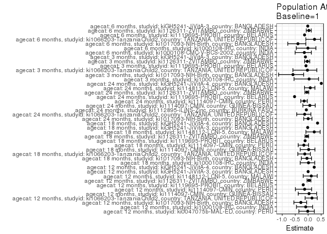

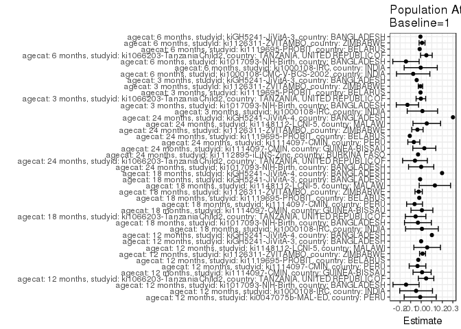

## Results Table

### Parameter: TSM

| agecat | studyid | country | intervention_level | baseline_level | estimate | ci_lower | ci_upper |
| --- | --- | --- | --- | --- | --- | --- | --- |
| 3 months | ki1000108-IRC | INDIA | 1 | NA | 0.3055556 | 0.1548980 | 0.4562131 |
| 3 months | ki1000108-IRC | INDIA | 2 | NA | 0.4074074 | 0.2218454 | 0.5929694 |
| 3 months | ki1000108-IRC | INDIA | 3 | NA | 0.3793103 | 0.2024974 | 0.5561233 |
| 3 months | ki1000108-IRC | INDIA | 4 | NA | 0.3636364 | 0.1623783 | 0.5648945 |
| 3 months | ki1000108-IRC | INDIA | 5 | NA | 0.3333333 | 0.1314677 | 0.5351990 |
| 3 months | ki1000108-IRC | INDIA | 6 | NA | 0.2702703 | 0.1269995 | 0.4135411 |
| 3 months | ki1000108-IRC | INDIA | 7 | NA | 0.3055556 | 0.1548980 | 0.4562131 |
| 3 months | ki1000108-IRC | INDIA | 8 | NA | 0.1555556 | 0.0495325 | 0.2615786 |
| 3 months | ki1000108-IRC | INDIA | 9 | NA | 0.3333333 | 0.1553045 | 0.5113621 |
| 3 months | ki1000108-IRC | INDIA | 10 | NA | 0.2432432 | 0.1048305 | 0.3816560 |
| 3 months | ki1000108-IRC | INDIA | 11 | NA | 0.3170732 | 0.1744621 | 0.4596843 |
| 3 months | ki1000108-IRC | INDIA | 12 | NA | 0.4423077 | 0.3071514 | 0.5774640 |
| 3 months | ki1017093-NIH-Birth | BANGLADESH | 1 | NA | 0.3529412 | 0.2392669 | 0.4666154 |
| 3 months | ki1017093-NIH-Birth | BANGLADESH | 2 | NA | 0.2622951 | 0.1518198 | 0.3727704 |
| 3 months | ki1017093-NIH-Birth | BANGLADESH | 3 | NA | 0.1147541 | 0.0347072 | 0.1948010 |
| 3 months | ki1017093-NIH-Birth | BANGLADESH | 4 | NA | 0.2264151 | 0.1136532 | 0.3391770 |
| 3 months | ki1017093-NIH-Birth | BANGLADESH | 5 | NA | 0.1914894 | 0.0789097 | 0.3040690 |
| 3 months | ki1017093-NIH-Birth | BANGLADESH | 6 | NA | 0.2127660 | 0.0956684 | 0.3298635 |
| 3 months | ki1017093-NIH-Birth | BANGLADESH | 7 | NA | 0.1875000 | 0.0769941 | 0.2980059 |
| 3 months | ki1017093-NIH-Birth | BANGLADESH | 8 | NA | 0.1627907 | 0.0523597 | 0.2732217 |
| 3 months | ki1017093-NIH-Birth | BANGLADESH | 9 | NA | 0.2058824 | 0.0698613 | 0.3419034 |
| 3 months | ki1017093-NIH-Birth | BANGLADESH | 10 | NA | 0.2786885 | 0.1660856 | 0.3912914 |
| 3 months | ki1017093-NIH-Birth | BANGLADESH | 11 | NA | 0.2500000 | 0.1322143 | 0.3677857 |
| 3 months | ki1017093-NIH-Birth | BANGLADESH | 12 | NA | 0.1666667 | 0.0671879 | 0.2661454 |
| 3 months | ki1066203-TanzaniaChild2 | TANZANIA, UNITED REPUBLIC OF | 1 | NA | 0.1049383 | 0.0577347 | 0.1521418 |
| 3 months | ki1066203-TanzaniaChild2 | TANZANIA, UNITED REPUBLIC OF | 2 | NA | 0.1061453 | 0.0610121 | 0.1512784 |
| 3 months | ki1066203-TanzaniaChild2 | TANZANIA, UNITED REPUBLIC OF | 3 | NA | 0.0935673 | 0.0499086 | 0.1372259 |
| 3 months | ki1066203-TanzaniaChild2 | TANZANIA, UNITED REPUBLIC OF | 4 | NA | 0.1141304 | 0.0681773 | 0.1600836 |
| 3 months | ki1066203-TanzaniaChild2 | TANZANIA, UNITED REPUBLIC OF | 5 | NA | 0.1105263 | 0.0659339 | 0.1551188 |
| 3 months | ki1066203-TanzaniaChild2 | TANZANIA, UNITED REPUBLIC OF | 6 | NA | 0.0975610 | 0.0521392 | 0.1429827 |

[output cut: 486 more lines]

### Parameter: E(Y)

| agecat | studyid | country | intervention_level | baseline_level | estimate | ci_lower | ci_upper |
| --- | --- | --- | --- | --- | --- | --- | --- |
| 3 months | ki1000108-IRC | INDIA | NA | NA | 0.3170732 | 0.2719756 | 0.3621708 |
| 3 months | ki1017093-NIH-Birth | BANGLADESH | NA | NA | 0.2225755 | 0.1900416 | 0.2551094 |
| 3 months | ki1066203-TanzaniaChild2 | TANZANIA, UNITED REPUBLIC OF | NA | NA | 0.1019641 | 0.0898375 | 0.1140906 |
| 3 months | ki1119695-PROBIT | BELARUS | NA | NA | 0.0740923 | NA | NA |
| 3 months | ki1126311-ZVITAMBO | ZIMBABWE | NA | NA | 0.2096244 | 0.2028831 | 0.2163658 |
| 3 months | kiGH5241-JiVitA-3 | BANGLADESH | NA | NA | 0.4033513 | NA | NA |
| 6 months | ki1000108-CMC-V-BCS-2002 | INDIA | NA | NA | 0.5122616 | 0.4610525 | 0.5634707 |
| 6 months | ki1000108-IRC | INDIA | NA | NA | 0.4240196 | 0.3760078 | 0.4720314 |
| 6 months | ki1017093-NIH-Birth | BANGLADESH | NA | NA | 0.3647913 | 0.3245616 | 0.4050210 |
| 6 months | ki1066203-TanzaniaChild2 | TANZANIA, UNITED REPUBLIC OF | NA | NA | 0.2000895 | 0.1834961 | 0.2166830 |
| 6 months | ki1119695-PROBIT | BELARUS | NA | NA | 0.1042654 | NA | NA |
| 6 months | ki1126311-ZVITAMBO | ZIMBABWE | NA | NA | 0.2946488 | 0.2852724 | 0.3040252 |
| 6 months | kiGH5241-JiVitA-3 | BANGLADESH | NA | NA | 0.4254167 | NA | NA |
| 12 months | ki0047075b-MAL-ED | PERU | NA | NA | 0.5185185 | 0.4588090 | 0.5782281 |
| 12 months | ki1000108-IRC | INDIA | NA | NA | 0.5073529 | 0.4587823 | 0.5559236 |
| 12 months | ki1017093-NIH-Birth | BANGLADESH | NA | NA | 0.5101664 | 0.4680034 | 0.5523294 |
| 12 months | ki1066203-TanzaniaChild2 | TANZANIA, UNITED REPUBLIC OF | NA | NA | 0.3171343 | 0.2967138 | 0.3375547 |
| 12 months | ki1114097-CMIN | GUINEA-BISSAU | NA | NA | 0.2470085 | 0.2222861 | 0.2717310 |
| 12 months | ki1114097-CMIN | PERU | NA | NA | 0.2548476 | 0.2230391 | 0.2866562 |
| 12 months | ki1119695-PROBIT | BELARUS | NA | NA | 0.1456628 | NA | NA |
| 12 months | ki1126311-ZVITAMBO | ZIMBABWE | NA | NA | 0.3769185 | 0.3674967 | 0.3863403 |
| 12 months | ki1148112-LCNI-5 | MALAWI | NA | NA | 0.4748466 | 0.4405418 | 0.5091515 |
| 12 months | kiGH5241-JiVitA-3 | BANGLADESH | NA | NA | 0.4517670 | NA | NA |
| 12 months | kiGH5241-JiVitA-4 | BANGLADESH | NA | NA | 0.4345070 | NA | NA |
| 18 months | ki1000108-IRC | INDIA | NA | NA | 0.5623472 | 0.5142095 | 0.6104849 |
| 18 months | ki1017093-NIH-Birth | BANGLADESH | NA | NA | 0.6498994 | 0.6079209 | 0.6918779 |
| 18 months | ki1066203-TanzaniaChild2 | TANZANIA, UNITED REPUBLIC OF | NA | NA | 0.4044017 | 0.3791669 | 0.4296364 |
| 18 months | ki1114097-CMIN | GUINEA-BISSAU | NA | NA | 0.3704363 | 0.3421792 | 0.3986935 |
| 18 months | ki1114097-CMIN | PERU | NA | NA | 0.3765244 | 0.3394193 | 0.4136295 |
| 18 months | ki1119695-PROBIT | BELARUS | NA | NA | 0.1565217 | NA | NA |
| 18 months | ki1126311-ZVITAMBO | ZIMBABWE | NA | NA | 0.4911943 | 0.4797002 | 0.5026883 |
| 18 months | ki1148112-LCNI-5 | MALAWI | NA | NA | 0.5547337 | 0.5172409 | 0.5922266 |
| 18 months | kiGH5241-JiVitA-3 | BANGLADESH | NA | NA | 0.5437807 | NA | NA |
| 18 months | kiGH5241-JiVitA-4 | BANGLADESH | NA | NA | 0.5477058 | NA | NA |
| 24 months | ki1017093-NIH-Birth | BANGLADESH | NA | NA | 0.7553191 | 0.7164122 | 0.7942261 |
| 24 months | ki1066203-TanzaniaChild2 | TANZANIA, UNITED REPUBLIC OF | NA | NA | 0.4333333 | 0.4019706 | 0.4646960 |
| 24 months | ki1112895-iLiNS-Zinc | BURKINA FASO | NA | NA | 0.4192377 | NA | NA |
| 24 months | ki1114097-CMIN | GUINEA-BISSAU | NA | NA | 0.4620431 | 0.4321146 | 0.4919716 |
| 24 months | ki1114097-CMIN | PERU | NA | NA | 0.4553415 | 0.4144586 | 0.4962244 |
| 24 months | ki1119695-PROBIT | BELARUS | NA | NA | 0.2061657 | NA | NA |
| 24 months | ki1126311-ZVITAMBO | ZIMBABWE | NA | NA | 0.7166489 | 0.6962411 | 0.7370566 |
| 24 months | ki1148112-LCNI-5 | MALAWI | NA | NA | 0.6528926 | 0.6182403 | 0.6875448 |
| 24 months | kiGH5241-JiVitA-4 | BANGLADESH | NA | NA | 0.5953177 | NA | NA |

### Parameter: RR

| agecat | studyid | country | intervention_level | baseline_level | estimate | ci_lower | ci_upper |
| --- | --- | --- | --- | --- | --- | --- | --- |
| 3 months | ki1000108-IRC | INDIA | 1 | 1 | 1.0000000 | 1.0000000 | 1.0000000 |
| 3 months | ki1000108-IRC | INDIA | 2 | 1 | 1.3333333 | 0.6814329 | 2.6088816 |
| 3 months | ki1000108-IRC | INDIA | 3 | 1 | 1.2413793 | 0.6298310 | 2.4467239 |
| 3 months | ki1000108-IRC | INDIA | 4 | 1 | 1.1900826 | 0.5671051 | 2.4974150 |
| 3 months | ki1000108-IRC | INDIA | 5 | 1 | 1.0909091 | 0.4996127 | 2.3820103 |
| 3 months | ki1000108-IRC | INDIA | 6 | 1 | 0.8845209 | 0.4288412 | 1.8243985 |
| 3 months | ki1000108-IRC | INDIA | 7 | 1 | 1.0000000 | 0.4979310 | 2.0083104 |
| 3 months | ki1000108-IRC | INDIA | 8 | 1 | 0.5090909 | 0.2195112 | 1.1806847 |
| 3 months | ki1000108-IRC | INDIA | 9 | 1 | 1.0909091 | 0.5273606 | 2.2566771 |
| 3 months | ki1000108-IRC | INDIA | 10 | 1 | 0.7960688 | 0.3749359 | 1.6902239 |
| 3 months | ki1000108-IRC | INDIA | 11 | 1 | 1.0376940 | 0.5323862 | 2.0226084 |
| 3 months | ki1000108-IRC | INDIA | 12 | 1 | 1.4475524 | 0.8104244 | 2.5855688 |
| 3 months | ki1017093-NIH-Birth | BANGLADESH | 1 | 1 | 1.0000000 | 1.0000000 | 1.0000000 |
| 3 months | ki1017093-NIH-Birth | BANGLADESH | 2 | 1 | 0.7431694 | 0.4373374 | 1.2628710 |
| 3 months | ki1017093-NIH-Birth | BANGLADESH | 3 | 1 | 0.3251366 | 0.1507959 | 0.7010388 |
| 3 months | ki1017093-NIH-Birth | BANGLADESH | 4 | 1 | 0.6415094 | 0.3545050 | 1.1608703 |
| 3 months | ki1017093-NIH-Birth | BANGLADESH | 5 | 1 | 0.5425532 | 0.2775300 | 1.0606565 |
| 3 months | ki1017093-NIH-Birth | BANGLADESH | 6 | 1 | 0.6028369 | 0.3186116 | 1.1406123 |
| 3 months | ki1017093-NIH-Birth | BANGLADESH | 7 | 1 | 0.5312500 | 0.2714030 | 1.0398802 |
| 3 months | ki1017093-NIH-Birth | BANGLADESH | 8 | 1 | 0.4612403 | 0.2176701 | 0.9773627 |
| 3 months | ki1017093-NIH-Birth | BANGLADESH | 9 | 1 | 0.5833333 | 0.2797118 | 1.2165298 |
| 3 months | ki1017093-NIH-Birth | BANGLADESH | 10 | 1 | 0.7896175 | 0.4709920 | 1.3237927 |
| 3 months | ki1017093-NIH-Birth | BANGLADESH | 11 | 1 | 0.7083333 | 0.4002965 | 1.2534113 |
| 3 months | ki1017093-NIH-Birth | BANGLADESH | 12 | 1 | 0.4722222 | 0.2396606 | 0.9304570 |
| 3 months | ki1066203-TanzaniaChild2 | TANZANIA, UNITED REPUBLIC OF | 1 | 1 | 1.0000000 | 1.0000000 | 1.0000000 |
| 3 months | ki1066203-TanzaniaChild2 | TANZANIA, UNITED REPUBLIC OF | 2 | 1 | 1.0115018 | 0.5446868 | 1.8783932 |
| 3 months | ki1066203-TanzaniaChild2 | TANZANIA, UNITED REPUBLIC OF | 3 | 1 | 0.8916409 | 0.4663540 | 1.7047639 |
| 3 months | ki1066203-TanzaniaChild2 | TANZANIA, UNITED REPUBLIC OF | 4 | 1 | 1.0875959 | 0.5946793 | 1.9890802 |
| 3 months | ki1066203-TanzaniaChild2 | TANZANIA, UNITED REPUBLIC OF | 5 | 1 | 1.0532508 | 0.5755856 | 1.9273192 |
| 3 months | ki1066203-TanzaniaChild2 | TANZANIA, UNITED REPUBLIC OF | 6 | 1 | 0.9296987 | 0.4866196 | 1.7762125 |

[output cut: 486 more lines]

### Parameter: PAR

| agecat | studyid | country | intervention_level | baseline_level | estimate | ci_lower | ci_upper |
| --- | --- | --- | --- | --- | --- | --- | --- |
| 3 months | ki1000108-IRC | INDIA | 1 | NA | 0.0115176 | -0.1325156 | 0.1555508 |
| 3 months | ki1017093-NIH-Birth | BANGLADESH | 1 | NA | -0.1303657 | -0.2361314 | -0.0246000 |
| 3 months | ki1066203-TanzaniaChild2 | TANZANIA, UNITED REPUBLIC OF | 1 | NA | -0.0029742 | -0.0485104 | 0.0425620 |
| 3 months | ki1119695-PROBIT | BELARUS | 1 | NA | -0.0062998 | NA | NA |
| 3 months | ki1126311-ZVITAMBO | ZIMBABWE | 1 | NA | -0.0070666 | -0.0277957 | 0.0136625 |
| 3 months | kiGH5241-JiVitA-3 | BANGLADESH | 1 | NA | -0.0427902 | NA | NA |
| 6 months | ki1000108-CMC-V-BCS-2002 | INDIA | 1 | NA | -0.0759737 | -0.2340214 | 0.0820739 |
| 6 months | ki1000108-IRC | INDIA | 1 | NA | -0.0045518 | -0.1614826 | 0.1523789 |
| 6 months | ki1017093-NIH-Birth | BANGLADESH | 1 | NA | -0.1442996 | -0.2692576 | -0.0193417 |
| 6 months | ki1066203-TanzaniaChild2 | TANZANIA, UNITED REPUBLIC OF | 1 | NA | 0.0487737 | -0.0067282 | 0.1042757 |
| 6 months | ki1119695-PROBIT | BELARUS | 1 | NA | -0.0144846 | NA | NA |
| 6 months | ki1126311-ZVITAMBO | ZIMBABWE | 1 | NA | 0.0079821 | -0.0200861 | 0.0360503 |
| 6 months | kiGH5241-JiVitA-3 | BANGLADESH | 1 | NA | -0.0072209 | NA | NA |
| 12 months | ki0047075b-MAL-ED | PERU | 1 | NA | -0.0092593 | -0.1613787 | 0.1428602 |
| 12 months | ki1000108-IRC | INDIA | 1 | NA | -0.0482026 | -0.2034776 | 0.1070724 |
| 12 months | ki1017093-NIH-Birth | BANGLADESH | 1 | NA | -0.1436798 | -0.2674076 | -0.0199520 |
| 12 months | ki1066203-TanzaniaChild2 | TANZANIA, UNITED REPUBLIC OF | 1 | NA | 0.0464576 | -0.0267644 | 0.1196795 |
| 12 months | ki1114097-CMIN | GUINEA-BISSAU | 1 | NA | 0.0083722 | -0.0773900 | 0.0941343 |
| 12 months | ki1114097-CMIN | PERU | 1 | NA | -0.0348720 | -0.1137207 | 0.0439767 |
| 12 months | ki1119695-PROBIT | BELARUS | 1 | NA | -0.0276439 | NA | NA |
| 12 months | ki1126311-ZVITAMBO | ZIMBABWE | 1 | NA | 0.0127394 | -0.0155251 | 0.0410040 |
| 12 months | ki1148112-LCNI-5 | MALAWI | 1 | NA | 0.0566648 | -0.0694101 | 0.1827397 |
| 12 months | kiGH5241-JiVitA-3 | BANGLADESH | 1 | NA | -0.0006140 | NA | NA |
| 12 months | kiGH5241-JiVitA-4 | BANGLADESH | 1 | NA | 0.1011737 | NA | NA |
| 18 months | ki1000108-IRC | INDIA | 1 | NA | 0.0067916 | -0.1483848 | 0.1619680 |
| 18 months | ki1017093-NIH-Birth | BANGLADESH | 1 | NA | -0.0309517 | -0.1582003 | 0.0962970 |
| 18 months | ki1066203-TanzaniaChild2 | TANZANIA, UNITED REPUBLIC OF | 1 | NA | -0.0530452 | -0.1503801 | 0.0442898 |
| 18 months | ki1114097-CMIN | GUINEA-BISSAU | 1 | NA | 0.0068000 | -0.0969728 | 0.1105727 |
| 18 months | ki1114097-CMIN | PERU | 1 | NA | -0.0628695 | -0.1381490 | 0.0124099 |
| 18 months | ki1119695-PROBIT | BELARUS | 1 | NA | -0.0185837 | NA | NA |
| 18 months | ki1126311-ZVITAMBO | ZIMBABWE | 1 | NA | -0.0242119 | -0.0590259 | 0.0106021 |
| 18 months | ki1148112-LCNI-5 | MALAWI | 1 | NA | 0.1297337 | -0.0190207 | 0.2784882 |
| 18 months | kiGH5241-JiVitA-3 | BANGLADESH | 1 | NA | -0.0101409 | NA | NA |
| 18 months | kiGH5241-JiVitA-4 | BANGLADESH | 1 | NA | 0.1977058 | NA | NA |
| 24 months | ki1017093-NIH-Birth | BANGLADESH | 1 | NA | -0.0002364 | -0.1197695 | 0.1192967 |
| 24 months | ki1066203-TanzaniaChild2 | TANZANIA, UNITED REPUBLIC OF | 1 | NA | -0.0589744 | -0.1763115 | 0.0583627 |
| 24 months | ki1112895-iLiNS-Zinc | BURKINA FASO | 1 | NA | -0.0297418 | NA | NA |
| 24 months | ki1114097-CMIN | GUINEA-BISSAU | 1 | NA | 0.0296107 | -0.0793832 | 0.1386046 |
| 24 months | ki1114097-CMIN | PERU | 1 | NA | -0.0701687 | -0.1267913 | -0.0135461 |
| 24 months | ki1119695-PROBIT | BELARUS | 1 | NA | -0.1081200 | NA | NA |
| 24 months | ki1126311-ZVITAMBO | ZIMBABWE | 1 | NA | -0.0356034 | -0.0892562 | 0.0180495 |
| 24 months | ki1148112-LCNI-5 | MALAWI | 1 | NA | 0.0528926 | -0.0779581 | 0.1837433 |
| 24 months | kiGH5241-JiVitA-4 | BANGLADESH | 1 | NA | 0.3012001 | NA | NA |

### Parameter: PAF

| agecat | studyid | country | intervention_level | baseline_level | estimate | ci_lower | ci_upper |
| --- | --- | --- | --- | --- | --- | --- | --- |
| 3 months | ki1000108-IRC | INDIA | 1 | NA | 0.0363248 | -0.5440011 | 0.3985303 |
| 3 months | ki1017093-NIH-Birth | BANGLADESH | 1 | NA | -0.5857143 | -1.1388248 | -0.1756408 |
| 3 months | ki1066203-TanzaniaChild2 | TANZANIA, UNITED REPUBLIC OF | 1 | NA | -0.0291692 | -0.5883172 | 0.3331375 |
| 3 months | ki1119695-PROBIT | BELARUS | 1 | NA | -0.0850270 | NA | NA |
| 3 months | ki1126311-ZVITAMBO | ZIMBABWE | 1 | NA | -0.0337109 | -0.1374791 | 0.0605910 |
| 3 months | kiGH5241-JiVitA-3 | BANGLADESH | 1 | NA | -0.1060867 | NA | NA |
| 6 months | ki1000108-CMC-V-BCS-2002 | INDIA | 1 | NA | -0.1483104 | -0.5029207 | 0.1226305 |
| 6 months | ki1000108-IRC | INDIA | 1 | NA | -0.0107349 | -0.4576862 | 0.2991735 |
| 6 months | ki1017093-NIH-Birth | BANGLADESH | 1 | NA | -0.3955676 | -0.7859518 | -0.0905160 |
| 6 months | ki1066203-TanzaniaChild2 | TANZANIA, UNITED REPUBLIC OF | 1 | NA | 0.2437596 | -0.0906713 | 0.4756444 |
| 6 months | ki1119695-PROBIT | BELARUS | 1 | NA | -0.1389205 | NA | NA |
| 6 months | ki1126311-ZVITAMBO | ZIMBABWE | 1 | NA | 0.0270902 | -0.0729884 | 0.1178344 |
| 6 months | kiGH5241-JiVitA-3 | BANGLADESH | 1 | NA | -0.0169737 | NA | NA |
| 12 months | ki0047075b-MAL-ED | PERU | 1 | NA | -0.0178571 | -0.3578932 | 0.2370290 |
| 12 months | ki1000108-IRC | INDIA | 1 | NA | -0.0950081 | -0.4483306 | 0.1721209 |
| 12 months | ki1017093-NIH-Birth | BANGLADESH | 1 | NA | -0.2816332 | -0.5508692 | -0.0591375 |
| 12 months | ki1066203-TanzaniaChild2 | TANZANIA, UNITED REPUBLIC OF | 1 | NA | 0.1464918 | -0.1185883 | 0.3487540 |
| 12 months | ki1114097-CMIN | GUINEA-BISSAU | 1 | NA | 0.0338943 | -0.3838866 | 0.3255515 |
| 12 months | ki1114097-CMIN | PERU | 1 | NA | -0.1368346 | -0.4922882 | 0.1339522 |
| 12 months | ki1119695-PROBIT | BELARUS | 1 | NA | -0.1897802 | NA | NA |
| 12 months | ki1126311-ZVITAMBO | ZIMBABWE | 1 | NA | 0.0337989 | -0.0441772 | 0.1059520 |
| 12 months | ki1148112-LCNI-5 | MALAWI | 1 | NA | 0.1193329 | -0.1906533 | 0.3486142 |
| 12 months | kiGH5241-JiVitA-3 | BANGLADESH | 1 | NA | -0.0013591 | NA | NA |
| 12 months | kiGH5241-JiVitA-4 | BANGLADESH | 1 | NA | 0.2328471 | NA | NA |
| 18 months | ki1000108-IRC | INDIA | 1 | NA | 0.0120773 | -0.3062621 | 0.2528366 |
| 18 months | ki1017093-NIH-Birth | BANGLADESH | 1 | NA | -0.0476253 | -0.2629991 | 0.1310217 |
| 18 months | ki1066203-TanzaniaChild2 | TANZANIA, UNITED REPUBLIC OF | 1 | NA | -0.1311695 | -0.3994743 | 0.0856964 |
| 18 months | ki1114097-CMIN | GUINEA-BISSAU | 1 | NA | 0.0183566 | -0.3058425 | 0.2620674 |
| 18 months | ki1114097-CMIN | PERU | 1 | NA | -0.1669734 | -0.3853831 | 0.0170034 |
| 18 months | ki1119695-PROBIT | BELARUS | 1 | NA | -0.1187295 | NA | NA |
| 18 months | ki1126311-ZVITAMBO | ZIMBABWE | 1 | NA | -0.0492919 | -0.1226269 | 0.0192526 |
| 18 months | ki1148112-LCNI-5 | MALAWI | 1 | NA | 0.2338667 | -0.0878070 | 0.4604187 |
| 18 months | kiGH5241-JiVitA-3 | BANGLADESH | 1 | NA | -0.0186488 | NA | NA |
| 18 months | kiGH5241-JiVitA-4 | BANGLADESH | 1 | NA | 0.3609707 | NA | NA |
| 24 months | ki1017093-NIH-Birth | BANGLADESH | 1 | NA | -0.0003130 | -0.1717736 | 0.1460585 |
| 24 months | ki1066203-TanzaniaChild2 | TANZANIA, UNITED REPUBLIC OF | 1 | NA | -0.1360947 | -0.4420330 | 0.1049365 |
| 24 months | ki1112895-iLiNS-Zinc | BURKINA FASO | 1 | NA | -0.0709427 | NA | NA |
| 24 months | ki1114097-CMIN | GUINEA-BISSAU | 1 | NA | 0.0640864 | -0.2042295 | 0.2726185 |
| 24 months | ki1114097-CMIN | PERU | 1 | NA | -0.1541013 | -0.2861948 | -0.0355739 |
| 24 months | ki1119695-PROBIT | BELARUS | 1 | NA | -0.5244326 | NA | NA |
| 24 months | ki1126311-ZVITAMBO | ZIMBABWE | 1 | NA | -0.0496804 | -0.1273429 | 0.0226321 |
| 24 months | ki1148112-LCNI-5 | MALAWI | 1 | NA | 0.0810127 | -0.1430783 | 0.2611724 |
| 24 months | kiGH5241-JiVitA-4 | BANGLADESH | 1 | NA | 0.5059484 | NA | NA |